# Project 2

## Introduction

### Kaggle: https://www.kaggle.com/datasets/jainaru/dog-breeds-ranking-best-to-worst/data

This dataset explores 87 dog brees with 19 various characteristics that contributes to data’s ranking. It provides insights to help prospective dog owners make informed decisions based on breed-specific attributes like lifespan, grooming needs, and genetic ailments. This analysis is focused on the following variable or characteristics: Breed, Popularity Ranking, Number of Genetic Ailments, and Longevity.

```python
import matplotlib.pyplot as plt
import seaborn as sns
import numpy as np
import pandas as pd
import re
from sklearn import cluster, metrics, model_selection, linear_model
from sklearn.linear_model import LinearRegression
from sklearn.metrics import mean_squared_error, r2_score
```

```python
df = pd.read_csv('dogs-ranking-dataset.csv').dropna()
df
```

|  | Breed | type | score | popularity ranking | size | intelligence | congential ailments | score for kids | size.1 | $LIFETIME COST | INTELLIGENCE RANK | INTELLIGENCE % | LONGEVITY(YEARS) | NUMBER OF GENETIC AILMENTS | GENETIC AILMENTS | PURCHASE PRICE | FOOD COSTS PER YEAR | GROOMING FREQUNCY | SUITABILITY FOR CHILDREN |
| --- | --- | --- | --- | --- | --- | --- | --- | --- | --- | --- | --- | --- | --- | --- | --- | --- | --- | --- | --- |
| 0 | Border Terrier | terrier | 3.61 | 61 | 1 | Above average | none | 4.99 | small | $22,638 | 30 | 70% | 14.00 | 0 | none | $833 | $324 | Once a week | 1 |
| 1 | Cairn Terrier | terrier | 3.53 | 48 | 1 | Above average | 'lion jaw', heart problems | 4.91 | small | $21,992 | 35 | 61% | 13.84 | 2 | 'lion jaw', heart problems | $435 | $324 | Once a week | 1 |
| 2 | Siberian Husky | working | 3.22 | 16 | 2 | Average | none | 4.72 | medium | $22,049 | 45 | 45% | 12.58 | 0 | none | $650 | $466 | Once in a few weeks | 1 |
| 3 | Welsh Springer Spaniel | sporting | 3.34 | 81 | 2 | Above average | hip problems | 4.71 | medium | $20,224 | 31 | 69% | 12.49 | 1 | hip problems | $750 | $324 | Once a week | 1 |
| 4 | English Cocker Spaniel | sporting | 3.33 | 51 | 2 | Excellent | none | 4.70 | medium | $18,993 | 18 | 82% | 11.66 | 0 | none | $800 | $324 | Once a week | 1 |
| ... | ... | ... | ... | ... | ... | ... | ... | ... | ... | ... | ... | ... | ... | ... | ... | ... | ... | ... | ... |
| 82 | Alaskan Malamute | working | 1.82 | 47 | 3 | Average | hip problems, dwarfism | 2.57 | large | $21,986 | 50 | 36% | 10.67 | 2 | hip problems, dwarfism | $1,210 | $710 | Daily | 2 |
| 83 | Bloodhound | hound | 1.66 | 42 | 3 | Lowest | fatal stomach bloat, skin problems | 2.54 | large | $13,824 | 75 | 7% | 6.75 | 2 | fatal stomach bloat, skin problems | $608 | $710 | Once a week | 2 |
| 84 | Chow Chow | non-sporting | 1.76 | 54 | 2 | Lowest | eye, hip problems | 2.51 | medium | $15,898 | 77 | 5% | 9.01 | 2 | eye, hip problems | $515 | $466 | Daily | 2 |
| 85 | Akita | working | 1.95 | 41 | 3 | Average | hip problems | 2.33 | large | $20,994 | 54 | 31% | 10.16 | 1 | hip problems | $1,202 | $710 | Once a week | 3 |
| 86 | Bulldog | non-sporting | 0.99 | 6 | 2 | Lowest | breathing, hip, heart problems, 'dry eye' | 1.86 | medium | $13,479 | 78 | 3% | 6.29 | 5 | breathing, hip, heart problems, 'dry eye' | $2,680 | $466 | Once a week | 2 |

87 rows × 19 columns

### Data Cleaning

I want to filter the naming of the variable since some of them are in all capital letter, some in all small letter and I just want my data to be more readable. There are also some varibles that are described the same almost like a duplicate.

```python
# data cleaning
print(df.columns)
```

```
Index(['Breed', 'type', 'score', 'popularity ranking', 'size', 'intelligence',
       'congential ailments', 'score for kids', 'size.1', '$LIFETIME COST',
       'INTELLIGENCE RANK', 'INTELLIGENCE %', 'LONGEVITY(YEARS)',
       'NUMBER OF GENETIC AILMENTS', 'GENETIC AILMENTS', 'PURCHASE PRICE',
       'FOOD COSTS PER YEAR', 'GROOMING FREQUNCY', 'SUITABILITY FOR CHILDREN'],
      dtype='object')
```

```python
df.columns = df.columns.str.strip().str.title()
print(df.columns.tolist())
```

[output not shown]

```python
df =df.drop(columns=['Congential Ailments'])
```

```python
df['$Lifetime Cost'] = (
    df['$Lifetime Cost']
    .replace(r'[\$,]', '', regex=True)  # Remove $ and commas
    .astype(float)                     # Convert to float
)
```

```python
df
```

|  | Breed | Type | Score | Popularity Ranking | Size | Intelligence | Score For Kids | Size.1 | $Lifetime Cost | Intelligence Rank | Intelligence % | Longevity(Years) | Number Of Genetic Ailments | Genetic Ailments | Purchase Price | Food Costs Per Year | Grooming Frequncy | Suitability For Children |
| --- | --- | --- | --- | --- | --- | --- | --- | --- | --- | --- | --- | --- | --- | --- | --- | --- | --- | --- |
| 0 | Border Terrier | terrier | 3.61 | 61 | 1 | Above average | 4.99 | small | 22638.0 | 30 | 70% | 14.00 | 0 | none | $833 | $324 | Once a week | 1 |
| 1 | Cairn Terrier | terrier | 3.53 | 48 | 1 | Above average | 4.91 | small | 21992.0 | 35 | 61% | 13.84 | 2 | 'lion jaw', heart problems | $435 | $324 | Once a week | 1 |
| 2 | Siberian Husky | working | 3.22 | 16 | 2 | Average | 4.72 | medium | 22049.0 | 45 | 45% | 12.58 | 0 | none | $650 | $466 | Once in a few weeks | 1 |
| 3 | Welsh Springer Spaniel | sporting | 3.34 | 81 | 2 | Above average | 4.71 | medium | 20224.0 | 31 | 69% | 12.49 | 1 | hip problems | $750 | $324 | Once a week | 1 |
| 4 | English Cocker Spaniel | sporting | 3.33 | 51 | 2 | Excellent | 4.70 | medium | 18993.0 | 18 | 82% | 11.66 | 0 | none | $800 | $324 | Once a week | 1 |
| ... | ... | ... | ... | ... | ... | ... | ... | ... | ... | ... | ... | ... | ... | ... | ... | ... | ... | ... |
| 82 | Alaskan Malamute | working | 1.82 | 47 | 3 | Average | 2.57 | large | 21986.0 | 50 | 36% | 10.67 | 2 | hip problems, dwarfism | $1,210 | $710 | Daily | 2 |
| 83 | Bloodhound | hound | 1.66 | 42 | 3 | Lowest | 2.54 | large | 13824.0 | 75 | 7% | 6.75 | 2 | fatal stomach bloat, skin problems | $608 | $710 | Once a week | 2 |
| 84 | Chow Chow | non-sporting | 1.76 | 54 | 2 | Lowest | 2.51 | medium | 15898.0 | 77 | 5% | 9.01 | 2 | eye, hip problems | $515 | $466 | Daily | 2 |
| 85 | Akita | working | 1.95 | 41 | 3 | Average | 2.33 | large | 20994.0 | 54 | 31% | 10.16 | 1 | hip problems | $1,202 | $710 | Once a week | 3 |
| 86 | Bulldog | non-sporting | 0.99 | 6 | 2 | Lowest | 1.86 | medium | 13479.0 | 78 | 3% | 6.29 | 5 | breathing, hip, heart problems, 'dry eye' | $2,680 | $466 | Once a week | 2 |

87 rows × 18 columns

## Hypothesis Generation And Exploration

### Question 1: Which dogs are the most popular

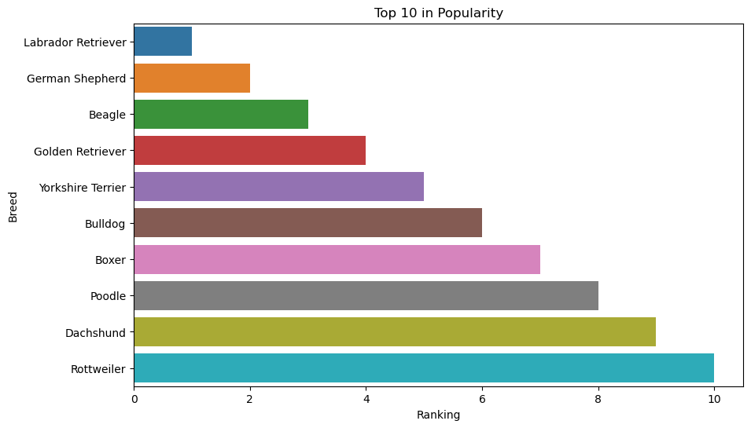

```python
top_10_popular = df.sort_values(by='Popularity Ranking', ascending=True).head(10)

plt.figure(figsize=(10,6))
sns.barplot(data=top_10_popular, x='Popularity Ranking', y='Breed', hue='Breed')
plt.title('Top 10 in Popularity')
plt.xlabel('Ranking')
plt.ylabel('Breed')
plt.show()
```

Explanation: For this question, I was just curious on which dog would be the most popular.

### Question 2: Which breed of dog have the longest lifespan?

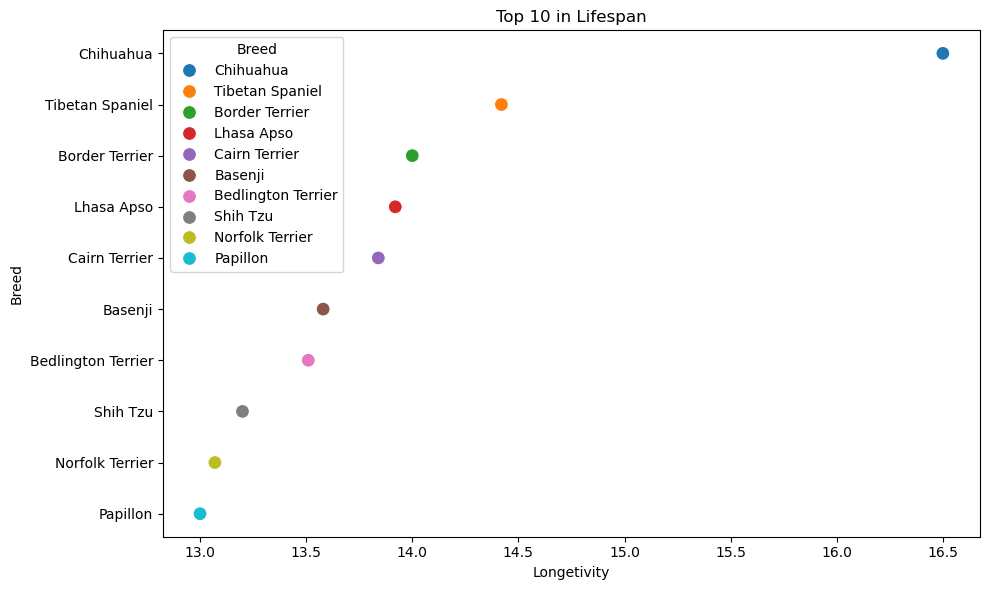

```python
top_breed_longevity = df.sort_values(by='Longevity(Years)', ascending=False).head(10)

# adding a breed palette to keep the assigned colors consistent
breeds = top_breed_longevity['Breed'].tolist()
palette = sns.color_palette('tab10', n_colors=len(breeds))
breed_palette = dict(zip(breeds, palette))

plt.figure(figsize=(10,6))
sns.scatterplot(data=top_breed_longevity, x='Longevity(Years)', y='Breed', hue='Breed', palette=breed_palette, s=100)
plt.title('Top 10 in Lifespan')
plt.xlabel('Longetivity')
plt.ylabel('Breed')
plt.tight_layout()
plt.savefig('top_breed_longevity.png', dpi=300)
```

Explanation: Putting myself in the perspective of getting a new dog, I wanted to know which dog has the longest lifespan if I am looking for a long term companion. My first impression of this plot was that I haven't heard of some of the dogs that are on the list other than 3-4 names. I thought it was also interesting that 4 types of terrier are on the list.

### Question 3: Which dogs have the shortest lifespan?

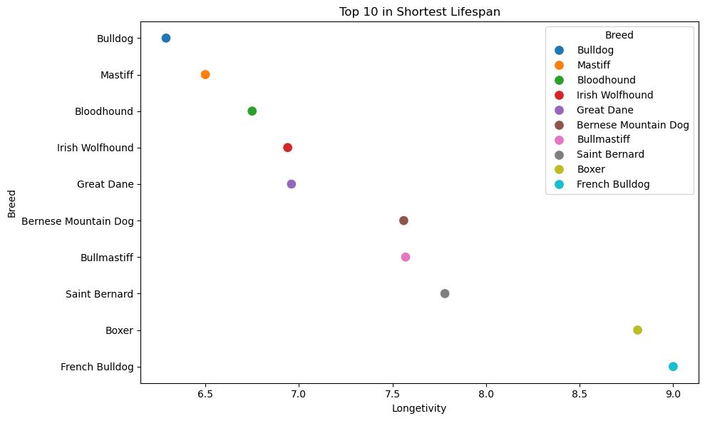

```python
top_breed_longevity = df.sort_values(by='Longevity(Years)', ascending=True).head(10)
plt.figure(figsize=(10,6))
sns.scatterplot(data=top_breed_longevity, x='Longevity(Years)', y='Breed', hue='Breed', s=100)
plt.title('Top 10 in Shortest Lifespan')
plt.xlabel('Longetivity')
plt.ylabel('Breed')
plt.tight_layout()
plt.savefig('top_breed_longevity.png', dpi=300)
```

Explanation: This is one of the question that I had after the presentation just out of curiosity.

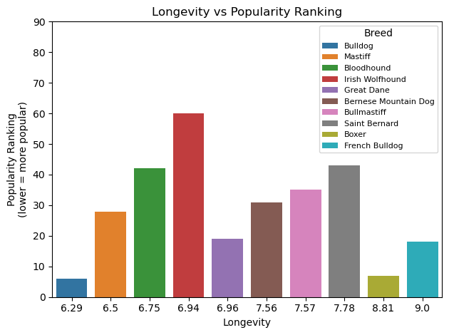

```python
top_breed_longevity = top_breed_longevity.sort_values(by='Popularity Ranking', ascending=True)

sns.barplot(
    data=top_breed_longevity,
    x='Longevity(Years)',
    y='Popularity Ranking',
    hue='Breed'
)

max_rank = df['Popularity Ranking'].max()
plt.yticks(np.arange(0, max_rank + 10, 10))

plt.legend(title='Breed', fontsize=8, title_fontsize=10)

plt.title('Longevity vs Popularity Ranking')
plt.xlabel('Longevity')
plt.ylabel('Popularity Ranking\n(lower = more popular)')
plt.tight_layout()
plt.savefig('bar_ranking.png', dpi=300)
```

## Machine Learning

### Question 5: Does the number of genetic ailment affect a breed's lifespan?

```
Intercept: 11.484068978169143
Coefficient: -0.2168299394606495
R2: 0.0365
RMSE: 1.8918
```

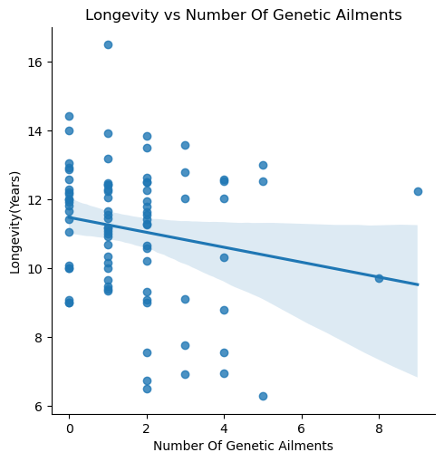

```python
sns.lmplot(data=df, x='Number Of Genetic Ailments', y='Longevity(Years)')
plt.title('Longevity vs Number Of Genetic Ailments')

X = df[['Number Of Genetic Ailments']]
y = df['Longevity(Years)']

model = LinearRegression()
model.fit(X, y)

y_pred = model.predict(X)

r2 = r2_score(y, y_pred)
rmse = np.sqrt(mean_squared_error(y, y_pred))

print(f'Intercept: {model.intercept_}')
print(f'Coefficient: {model.coef_[0]}')
print(f'R2: {r2:.4f}')
print(f'RMSE: {rmse:.4f}')
```

### Interpretations:

Independent: Number of Genetic Ailements

Dependent: Longevity(Years)

Do dogs with less number of genetic problems tend to live longer? If so, is there a big difference?

The intercept represents the predicted lifespan of a dog with zero ailment to be 11.5 years. Meanwhile the coefficient tells us how much of the lifespan decrease with each added ailment. In this case, each ailment will take off about 0.22 years in a dogs lifespan. Although it shows a negative linear relationship, the R2 score is very low indicating that it is a very weak linear relationship. This could be due to other factors affecting the lifespan of a dog. The RMSE is also 1.89, suggesting that the lifespan predictions are off by 2 years.

Overall, breeds with more ailments still tend to live slightly shorter than those with less. I also probably wouldn't recommend this model in the future just because it might not be reliable for prediction in the real world. The model also seems to be underfitting as it doesn't capture the other existing variables.

## Ethical Considerations

Benificence/Justince: The model is accessible to a wide audience and very informational to those who are seeking insights on which breed are compatible for their own interests. Such as potential dog owners that are ensuring ethical decision-making, responsible ownership, animal shelters, breeders, and anyone who is in research.

Public Interest: This data aligns with the public interest that are looking for selection advice and knowledge on taking care of certain breed.

## Conclusion

Understanding these aspects can help potential dog owners make more informed decisions when selecting a breed that fits their long-term expectations and care capabilities. This dataset also allows us to further research by creating models that contribute to positive ownership practices.